# EDA_tim

```python
import numpy as np
import pandas as pd

import matplotlib.pyplot as plt
```

```python
%matplotlib inline
plt.rcParams.update(
    {
        "figure.figsize":(12, 6),
        "image.aspect":"auto",
        "font.size":14,
    }
)
```

```python
train = pd.read_csv("../data/raw/train.csv")
test = pd.read_csv("../data/raw/test.csv")
```

```python
train.shape, test.shape
```

```
((159571, 8), (153164, 2))
```

```python
train.columns
```

```
Index(['id', 'comment_text', 'toxic', 'severe_toxic', 'obscene', 'threat',
       'insult', 'identity_hate'],
      dtype='object')
```

## Toxicity Dependencies

Lets look at the different types of toxicity label and see how much overlap there is between them.

```python
#seperate train data into inputs and labels
comments = train[["id", "comment_text"]].set_index("id")
train_labels = train.drop(["comment_text"], axis=1).set_index("id")
```

```python
train_labels.values.dtype
```

```
dtype('int64')
```

```python
tox_means = np.mean(train_labels)
tox_means
```

```
toxic            0.095844
severe_toxic     0.009996
obscene          0.052948
threat           0.002996
insult           0.049364
identity_hate    0.008805
dtype: float64
```

Lets look at the conditional probabilities of each kind of toxicity category given that it is positive for another kind of toxicity label.

```python
for col in train_labels.columns:
    print(train_labels.groupby(col).mean())
    print("\n")
```

```
       severe_toxic   obscene    threat    insult  identity_hate
toxic
0          0.000000  0.003625  0.000201  0.003694       0.000714
1          0.104289  0.518242  0.029358  0.480188       0.085131


                 toxic   obscene    threat    insult  identity_hate
severe_toxic
0             0.086716  0.043880  0.002317  0.041183       0.006912
1             1.000000  0.951097  0.070219  0.859561       0.196238


            toxic  severe_toxic    threat    insult  identity_hate
obscene
0        0.048755      0.000516  0.001171  0.011395       0.002468
1        0.938099      0.179548  0.035626  0.728489       0.122145


           toxic  severe_toxic   obscene    insult  identity_hate
threat
0       0.093310      0.009322  0.051215  0.047582       0.008215
1       0.939331      0.234310  0.629707  0.642259       0.205021


           toxic  severe_toxic   obscene    threat  identity_hate
insult
0       0.052408      0.001477  0.015123  0.001127       0.001615
1       0.932335      0.174051  0.781389  0.038974       0.147264


                  toxic  severe_toxic   obscene    threat    insult
identity_hate
0              0.088464      0.008105  0.046894  0.002403  0.042468
1              0.926690      0.222776  0.734520  0.069751  0.825623
```

So severe_toxic is always also toxic and severe toxic is nearly always obscene but rarely includes a threat. Insults are obscene 78% of the time (fun fact) and 82% of identity_hate comments are also insults but only 14% of insults are identity hate.

There is some really rich probabilistic structure in here. With only 6 binary variables we can simply build the complete probability table for all 64 possible combinations.

```python
joint_probs = train_labels.groupby(list(train_labels.columns)).size()/len(train)
joint_probs
```

```
toxic  severe_toxic  obscene  threat  insult  identity_hate
0      0             0        0       0       0                0.898321
                                              1                0.000338
                                      1       0                0.001886
                                              1                0.000175
                              1       0       0                0.000138
                                      1       0                0.000019
                     1        0       0       0                0.001987
                                              1                0.000019
                                      1       0                0.001134
                                              1                0.000113
                              1       0       0                0.000013
                                      1       0                0.000013
1      0             0        0       0       0                0.035508
                                              1                0.000852
```

[output cut: 28 more lines]

So 90% of the comments have no toxicity of any kind and not surprisingly comments which don't have the "toxic" label rarely have any other kind of toxicity label either. Of those comments that are positive for toxicity the most common combination is just the toxic label alone at 3.5% and after that the second most common combination is the combination toxcic, severe_toxic, obscene, and insult coming in at 2.2% and the next most common being the same but without the insult label coming in at 1%. The rest of the probabilities are really too diffuse to easily interpet. Lets simplify things a little by looking only at the probabilities for toxic coments and drop dependence on severe_toxic.

```python
sub_labels = train_labels.query("toxic == True")
sub_labels.groupby(["obscene", "threat", "insult", "identity_hate"]).size()/len(sub_labels)
```

```
obscene  threat  insult  identity_hate
0        0       0       0                0.373153
                         1                0.009089
                 1       0                0.080358
                         1                0.009219
         1       0       0                0.008108
                         1                0.000523
                 1       0                0.001112
                         1                0.000196
1        0       0       0                0.125278
                         1                0.002681
                 1       0                0.313129
                         1                0.057735
         1       0       0                0.000981
                 1       0                0.012750
                         1                0.005689
dtype: float64
```

There are some super strong conditional relationships here, only 41 of the 64 possible label combinations actually occur even once knowing the values of some of the more common labels can significantly improve our ability to predict some of the rarer ones. I'm not sure what the best way to take advantage of this structure might be. There are a few obvious things we could do like for example make sure that we always mark a comment as toxic if we mark it as severe toxic.

I think there may be other interesting things to do which may be better though. For example we can choose a factorization of the total probabilities above into a [bayesian network](https://en.wikipedia.org/wiki/Bayesian_network) where the observation is the comment and each conditional probability is provided by a different model (or an esemble of different models).

For example because severe toxic is a pure subset of toxic we can (and should I think) factorize the probability of severe_toxic as a conditional probability,

$$ p(ST=1) = P(ST=1 | T=1)P(T=1) + p(ST=1 | T=0)p(T=0) $$

Because you never have a severe toxic comment that isn't toxic the second term drops out and we have just P(ST) = P(ST | T)P(T). Factorizing the probability this way will automatically enforce the logical connection between toxic. We can implement P(T) as any sort of model (an LSTM, or a Logistic Regression on word count vectors whatever just so long as it gives us a probability). We can train P(T) on all the comment data and then train a P(ST | T) model using just those comments which are labeled as toxic. Actually so that the pool of training data roughly matches what we would see at predict time we should probably train P(ST |T) on all the data which passes some probability threshold for our toxicity detector as well as all the actually toxic comments.

This is potentially a complicated way to approach the problem since it would require training not just one model per type of toxicity but one model for every entry in the equivalent conditional probability table for our bayes net.

# Cross Category AUC ROC boost

In order to gauge the utility of using conditional probability models in this way I want to estimate what sort of AUC ROC scores we could get simply by predicting labels entirely based on the values of other toxicity classes. For comparison completely random label assignments would come in at a score of 0.5

```python
import sklearn.metrics

cross_aucs = np.ones((6, 6))

for row_idx, conditioning_col in enumerate(train_labels.columns):
    for col_idx, target_col in enumerate(train_labels.columns):
        if conditioning_col == target_col:
            continue
        cauc = sklearn.metrics.roc_auc_score(
            train_labels[target_col].values,
            train_labels[conditioning_col].values
        )
        cross_aucs[row_idx, col_idx] = cauc
        print("{:15s} standing in for   {:15s}  {:0.4f}".format(conditioning_col, target_col, cauc))
```

```
toxic           standing in for   severe_toxic     0.9566
toxic           standing in for   obscene          0.9447
toxic           standing in for   threat           0.9230
toxic           standing in for   insult           0.9400
toxic           standing in for   identity_hate    0.9191
severe_toxic    standing in for   toxic            0.5521
severe_toxic    standing in for   obscene          0.5895
severe_toxic    standing in for   threat           0.6125
severe_toxic    standing in for   insult           0.5863
severe_toxic    standing in for   identity_hate    0.6073
obscene         standing in for   toxic            0.7573
obscene         standing in for   severe_toxic     0.9536
obscene         standing in for   threat           0.7892
obscene         standing in for   insult           0.8831
obscene         standing in for   identity_hate    0.8438
threat          standing in for   toxic            0.5146
threat          standing in for   severe_toxic     0.5340
threat          standing in for   obscene          0.5172
threat          standing in for   insult           0.5189
threat          standing in for   identity_hate    0.5337
insult          standing in for   toxic            0.7382
insult          standing in for   severe_toxic     0.9092
insult          standing in for   obscene          0.8585
insult          standing in for   threat           0.7973
insult          standing in for   identity_hate    0.8916
identity_hate   standing in for   toxic            0.5422
identity_hate   standing in for   severe_toxic     0.5947
identity_hate   standing in for   obscene          0.5598
identity_hate   standing in for   threat           0.5984
identity_hate   standing in for   insult           0.5728
```

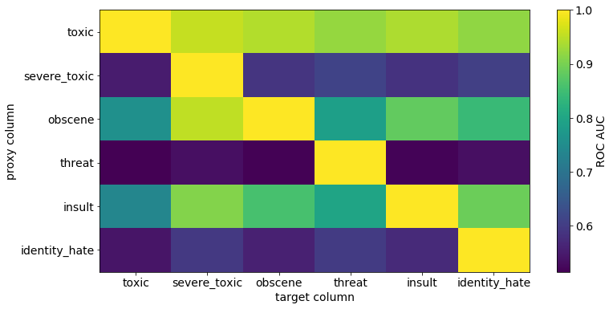

```python
plt.imshow(cross_aucs)
cbar = plt.colorbar()
cbar.set_label("ROC AUC")
plt.xlabel("target column")
plt.ylabel("proxy column")
plt.xticks(range(6), train_labels.columns)
plt.yticks(range(6), train_labels.columns);
```

Seen in table form it is clear that the best proxy columns are toxic, obscene, and insult. Intuitively these also seem like good variables to put close to the base of any bayes net factorization. Probably toxic makes sense to put as a dependency for every other kind of toxicity label. Lets look at just the joint probabilities of those three variables.

```python
joint_probs = train_labels.groupby(["toxic", "obscene", "insult"]).size()/len(train)
joint_probs
```

```
toxic  obscene  insult
0      0        0         0.898797
                1         0.002081
       1        0         0.002018
                1         0.001260
1      0        0         0.037463
                1         0.008711
       1        0         0.012358
                1         0.037313
dtype: float64
```

In total it looks like about half a percent of comments manage somehow to be either obscene or an insult (or both) without being labeled as toxic.

```python
#joint probabilities
df = pd.DataFrame()
df["toxic"] = train_labels["toxic"]
df["obscene_or_insult"] = np.logical_or(train_labels["obscene"], train_labels["insult"])
df.groupby(list(df.columns)).size()/len(df)
```

```
toxic  obscene_or_insult
0      False                0.898797
       True                 0.005358
1      False                0.037463
       True                 0.058382
dtype: float64
```

```python
#conditional probabilities
df.groupby("toxic").mean()
```

| toxic | obscene_or_insult |
| --- | --- |
| 0 | 0.005926 |
| 1 | 0.609128 |

# Character Distribution

For this competition I think I want to try and mess with character level models but it depends a little bit on whether or not I can count on the characters to be mostly restricted to the usual ascii or if I will end up having to deal with a bunch of random characters.

```python
import sklearn.feature_extraction

character_counter = sklearn.feature_extraction.text.CountVectorizer(
    analyzer="char",
    lowercase=False,
)

character_counter.fit(train["comment_text"].values)
```

```
CountVectorizer(analyzer='char', binary=False, decode_error='strict',
        dtype=<class 'numpy.int64'>, encoding='utf-8', input='content',
        lowercase=False, max_df=1.0, max_features=None, min_df=1,
        ngram_range=(1, 1), preprocessor=None, stop_words=None,
        strip_accents=None, token_pattern='(?u)\\b\\w\\w+\\b',
        tokenizer=None, vocabulary=None)
```

```python
len(character_counter.vocabulary_)
```

```
2334
```

```python
character_counts = character_counter.transform(train["comment_text"].values).toarray()
```

```
Text(0.5,0,'Log(occurence per comment)')
```

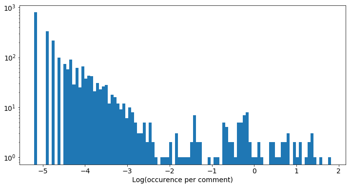

```python
mean_char_counts = np.mean(character_counts, axis=0)
plt.hist(np.log10(mean_char_counts), 101, log=True);
plt.xlabel("Log(occurence per comment)")
```

```python
np.sum(mean_char_counts > 1e-3)
```

```
148
```

```python
np.sum(mean_char_counts > 1e-4)
```

```
482
```

```python
np.sum(mean_char_counts > 3e-5)
```

```
886
```

So if we want to include all the characters that occur more frequently than about one per 1,000 comments we can do so using around 150 characters. But if we want to go all the way out to one per every 10,000 comments that would take over 400. What are the most frequent characters?

```python
ch_vocab = character_counter.vocabulary_
ordered_chars = [None for ch in ch_vocab]
for ch in character_counter.vocabulary_:
    ordered_chars[ch_vocab[ch]] = ch

ordered_chars = np.array(ordered_chars)

freq_sorted_chars = ordered_chars[np.argsort(-mean_char_counts)]
```

```python
freq_sorted_chars[:200]
```

```
array([' ', 'e', 't', 'a', 'o', 'i', 'n', 's', 'r', 'h', 'l', 'd', 'u',
       'c', 'm', 'y', 'p', 'g', 'f', 'w', 'b', '.', 'k', 'v', ',', 'I',
       '"', 'T', "'", 'A', 'S', 'W', 'C', 'E', 'P', 'O', 'N', 'H', '!',
       '1', '-', '0', 'R', ':', 'M', ')', 'x', 'B', 'D', '(', '2', 'U',
       'F', 'L', '?', 'j', '\n', 'G', 'Y', '/', 'K', 'q', 'z', '9', '3',
       'J', '5', '4', '=', '8', '6', '7', 'V', ';', '_', '|', ']', '[',
       '~', '&', '—', '{', '#', '}', '•', 'Q', '%', '*', 'Z', 'X', '’',
       '+', '–', '“', '”', '\xa0', '>', '@', '·', 'é', '$', '^', '\u200e',
       '→', '`', '\\', '´', '<', '‘', 'а', 'о', 'á', '…', 'е', 'и', 'ü',
       'ö', 'н', 'ا', 'í', 'α', 'р', 'ı', 'ó', 'ل', 'т', 'с', 'ä', 'ć',
       'к', 'ç', '♥', 'в', 'л', '←', '♦', 'ā', '►', 'ε', 'τ', '✉', '☎',
       '§', 'م', '°', 'д', '♫', 'у', 'š', '£', 'ο', '»', 'و', '♣', 'ي',
       'п', '★', 'ς', '™', 'ن', '«', 'м', 'λ', '©', 'ر', 'ν', 'ι', '♪',
       'ş', '♠', '−', '☺', 'è', 'ł', 'č', '†', 'å', 'æ', 'â', 'б', 'ρ',
       'ب', 'η', '≈', 'à', '\u200b', 'ñ', 'ع', 'ō', '¡', 'я', 'ω', 'ه',
       'ø', '்', '®', 'ə', 'ë', 'ú', '∆'],
      dtype='<U1')
```

I think it is more important that we keep the characters that occur more frequently in the toxic comments than it is that we keep the most common characters overall. The frequency of some characters may shift with toxicity.

```python
mean_toxic_char_counts = np.mean(character_counts[train_labels["toxic"] == 1], axis=0)
```

```python
freq_sorted_chars_toxic = ordered_chars[np.argsort(-mean_toxic_char_counts)]
freq_sorted_chars_toxic[:200]
```

```
array([' ', 'e', 'o', 'a', 't', 'i', 'n', 's', 'r', 'u', 'h', 'l', 'd',
       'y', 'c', 'g', 'm', 'I', 'f', '!', '.', 'p', 'A', 'k', 'E', 'w',
       'O', 'b', 'S', 'T', 'U', 'C', 'N', 'H', ',', 'R', 'v', 'Y', 'F',
       'L', 'G', 'K', 'D', 'W', '"', 'B', "'", 'M', 'P', '?', '1', '\n',
       '-', '=', 'x', 'j', '2', '/', '0', 'J', 'V', ':', ')', '3', '9',
       'z', '(', '8', '7', '4', '6', '5', 'q', '*', '_', 'X', 'Z', ';',
       '|', '~', 'Q', '@', ']', '[', '&', '+', '%', '#', '—', '$', '}',
       '{', '’', '>', '\u200e', 'é', '\\', '^', '”', '<', '•', '´', '`',
       'ţ', '“', '–', 'ś', '\xa0', 'а', '·', 'ο', 'ŷ', '⟲', 'ģ', '♥', 'ı',
       'ŵ', 'ç', '→', 'ṃ', 'ṗ', 'и', '♣', '¯', '…', 'ä', '►', 'н', '☺',
       'α', '♫', '\xad', '☻', '♪', 'т', 'с', '❝', 'ê', '➨', '‘', 'ε', 'Я',
       '❞', 'ƒ', 'ć', '←', '♦', '♠', '✉', 'о', '─', '★', 'ö', '₪', '§',
       'ل', 'ü', 'ą', 'á', 'д', '\ufeff', 'ا', 'р', 'е', '©', 'к', '☼',
       'ú', 'Δ', 'ï', '∞', 'ν', 'ṣ', 'σ', 'ι', '−', '∆', 'š', 'و', 'م',
       'й', 'מ', 'б', '✎', 'å', 'ō', 'ݣ', 'Š', 'л', 'п', '╟', 'ු', 'я',
       'ּ', 'ط', 'ع', 'ρ', 'ۻ', 'ݗ', 'τ'],
      dtype='<U1')
```

The exclamation mark jumps up significantly and so do capital letters many of the rarer symbols are very different though I don't know if that has any significance or not.